# Eleigant Graphics with R, Part 1

Sameh MAGDELDIN M.V.Sc, 2Ph.D

November, 2024

# Basic Graphics

## Topics to be covered in this section

> 1. Line chart
> 2. Bar chart
> 3. Histogram
> 4. Box and whisker plot
> 5. Combining plots
> 6. Scatterplot matrix

**R is an open source software designed mainly for data manipulation, powerful statistics and elegant graphics.**

**In this tutorial, i will show you how to use R for BASIC graphics [low level plotting commands]. The graphics function is mainly integrated in the base package that comes with R when you install it.**

**I’m giving an advanced tutorial for more sophisticated graphics using ggplot2 package.**

**Lets start**

*lets navigate some demo graphics of the base package in R*

```
##
##
##  demo(graphics)
##  ---- ~~~~~~~~
##
## > #  Copyright (C) 1997-2009 The R Core Team
## >
## > require(datasets)
##
## > require(grDevices); require(graphics)
##
## > ## Here is some code which illustrates some of the differences between
## > ## R and S graphics capabilities.  Note that colors are generally specified
## > ## by a character string name (taken from the X11 rgb.txt file) and that line
## > ## textures are given similarly.  The parameter "bg" sets the background
## > ## parameter for the plot and there is also an "fg" parameter which sets
## > ## the foreground color.
## >
## >
## > x <- stats::rnorm(50)
##
## > opar <- par(bg = "white")
##
## > plot(x, ann = FALSE, type = "n")
```

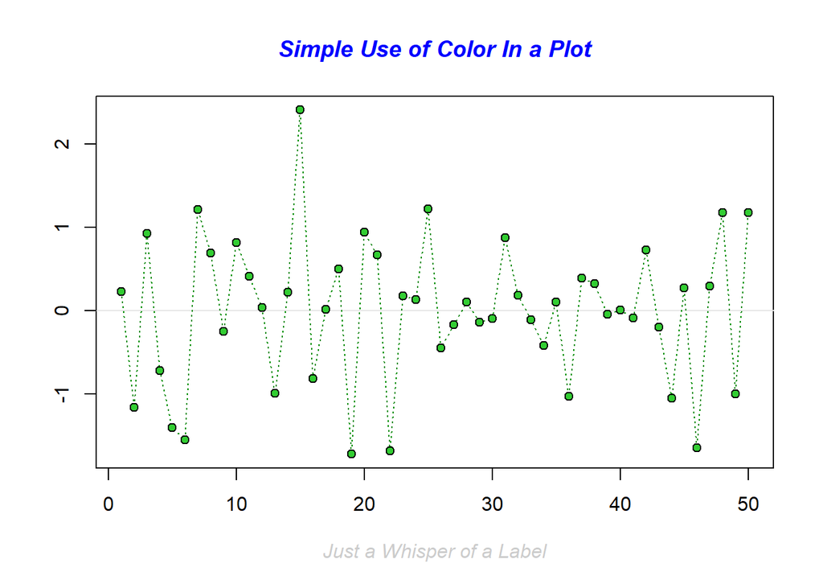

```
##
## > abline(h = 0, col = gray(.90))
##
## > lines(x, col = "green4", lty = "dotted")
##
## > points(x, bg = "limegreen", pch = 21)
##
## > title(main = "Simple Use of Color In a Plot",
## +       xlab = "Just a Whisper of a Label",
## +       col.main = "blue", col.lab = gray(.8),
## +       cex.main = 1.2, cex.lab = 1.0, font.main = 4, font.lab = 3)
##
## > ## A little color wheel.    This code just plots equally spaced hues in
## > ## a pie chart.    If you have a cheap SVGA monitor (like me) you will
## > ## probably find that numerically equispaced does not mean visually
## > ## equispaced.  On my display at home, these colors tend to cluster at
## > ## the RGB primaries.  On the other hand on the SGI Indy at work the
## > ## effect is near perfect.
## >
## > par(bg = "gray")
##
## > pie(rep(1,24), col = rainbow(24), radius = 0.9)
```

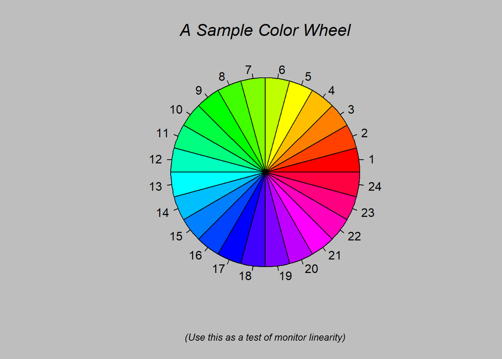

```
##
## > title(main = "A Sample Color Wheel", cex.main = 1.4, font.main = 3)
##
## > title(xlab = "(Use this as a test of monitor linearity)",
## +       cex.lab = 0.8, font.lab = 3)
##
## > ## We have already confessed to having these.  This is just showing off X11
## > ## color names (and the example (from the postscript manual) is pretty "cute".
## >
## > pie.sales <- c(0.12, 0.3, 0.26, 0.16, 0.04, 0.12)
##
## > names(pie.sales) <- c("Blueberry", "Cherry",
## +              "Apple", "Boston Cream", "Other", "Vanilla Cream")
##
## > pie(pie.sales,
## +     col = c("purple","violetred1","green3","cornsilk","cyan","white"))
```

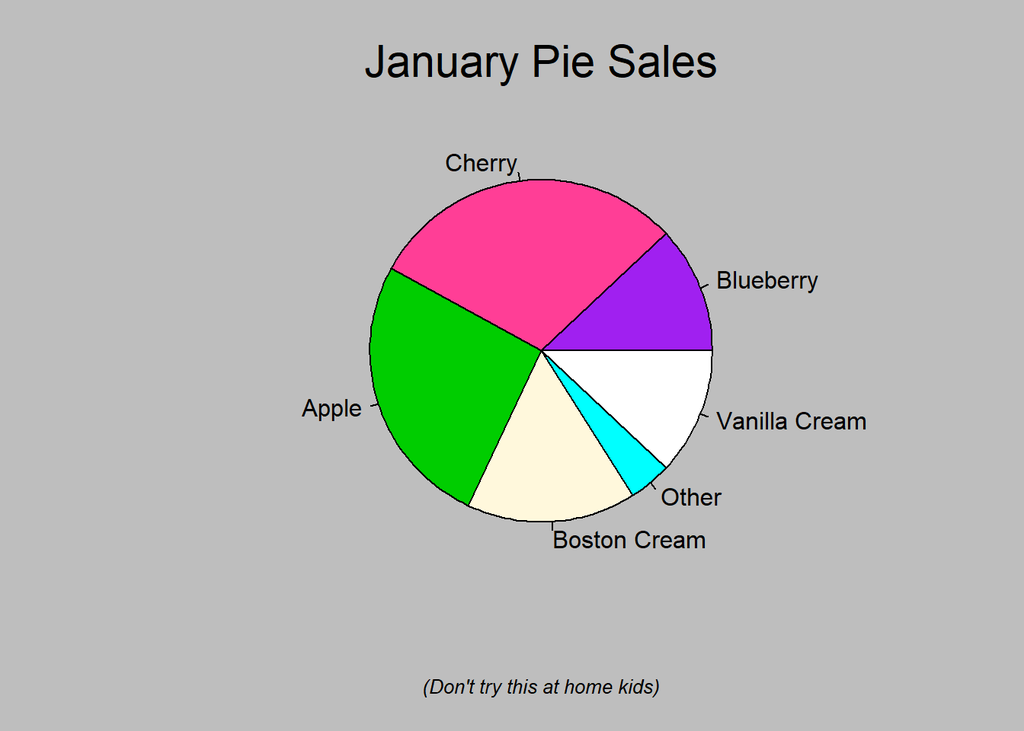

```
##
## > title(main = "January Pie Sales", cex.main = 1.8, font.main = 1)
##
## > title(xlab = "(Don't try this at home kids)", cex.lab = 0.8, font.lab = 3)
##
## > ## Boxplots:  I couldn't resist the capability for filling the "box".
## > ## The use of color seems like a useful addition, it focuses attention
## > ## on the central bulk of the data.
## >
## > par(bg="cornsilk")
##
## > n <- 10
##
## > g <- gl(n, 100, n*100)
##
## > x <- rnorm(n*100) + sqrt(as.numeric(g))
##
## > boxplot(split(x,g), col="lavender", notch=TRUE)
```

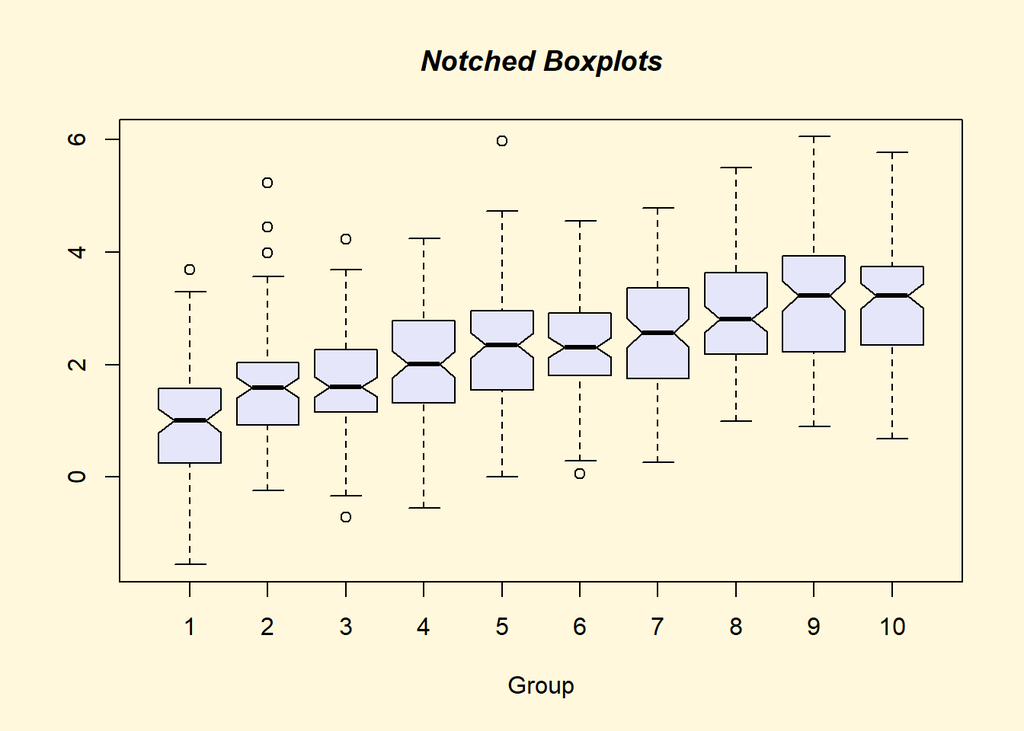

```
##
## > title(main="Notched Boxplots", xlab="Group", font.main=4, font.lab=1)
##
## > ## An example showing how to fill between curves.
## >
## > par(bg="white")
##
## > n <- 100
##
## > x <- c(0,cumsum(rnorm(n)))
##
## > y <- c(0,cumsum(rnorm(n)))
##
## > xx <- c(0:n, n:0)
##
## > yy <- c(x, rev(y))
##
## > plot(xx, yy, type="n", xlab="Time", ylab="Distance")
```

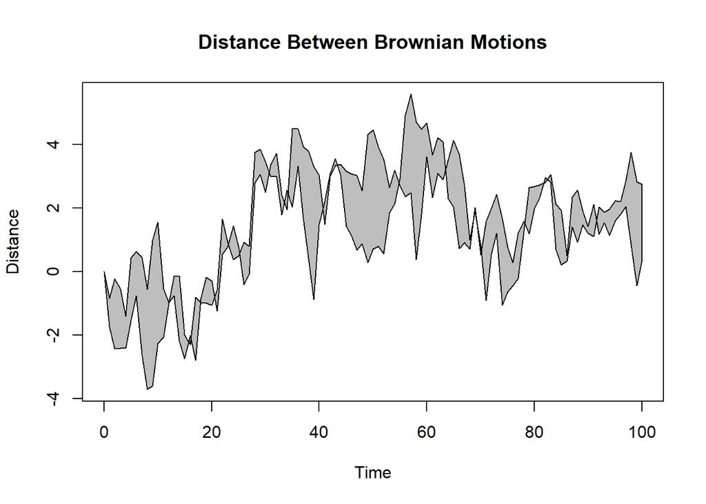

```
##
## > polygon(xx, yy, col="gray")
##
## > title("Distance Between Brownian Motions")
##
## > ## Colored plot margins, axis labels and titles.    You do need to be
## > ## careful with these kinds of effects.    It's easy to go completely
## > ## over the top and you can end up with your lunch all over the keyboard.
## > ## On the other hand, my market research clients love it.
## >
## > x <- c(0.00, 0.40, 0.86, 0.85, 0.69, 0.48, 0.54, 1.09, 1.11, 1.73, 2.05, 2.02)
##
## > par(bg="lightgray")
##
## > plot(x, type="n", axes=FALSE, ann=FALSE)
```

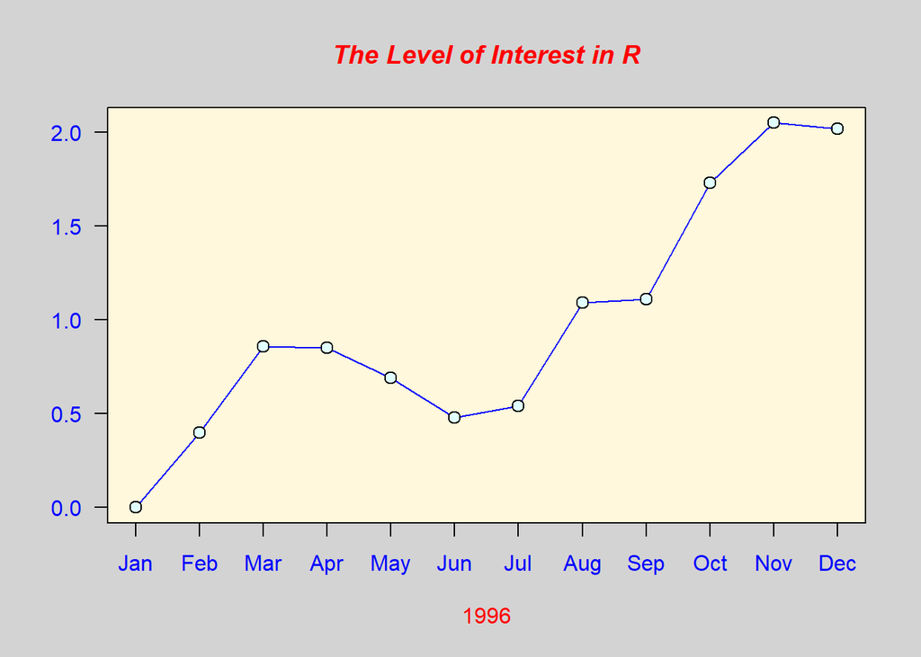

```
##
## > usr <- par("usr")
##
## > rect(usr[1], usr[3], usr[2], usr[4], col="cornsilk", border="black")
##
## > lines(x, col="blue")
##
## > points(x, pch=21, bg="lightcyan", cex=1.25)
##
## > axis(2, col.axis="blue", las=1)
##
## > axis(1, at=1:12, lab=month.abb, col.axis="blue")
##
## > box()
##
## > title(main= "The Level of Interest in R", font.main=4, col.main="red")
##
## > title(xlab= "1996", col.lab="red")
##
## > ## A filled histogram, showing how to change the font used for the
## > ## main title without changing the other annotation.
## >
## > par(bg="cornsilk")
##
## > x <- rnorm(1000)
##
## > hist(x, xlim=range(-4, 4, x), col="lavender", main="")
```

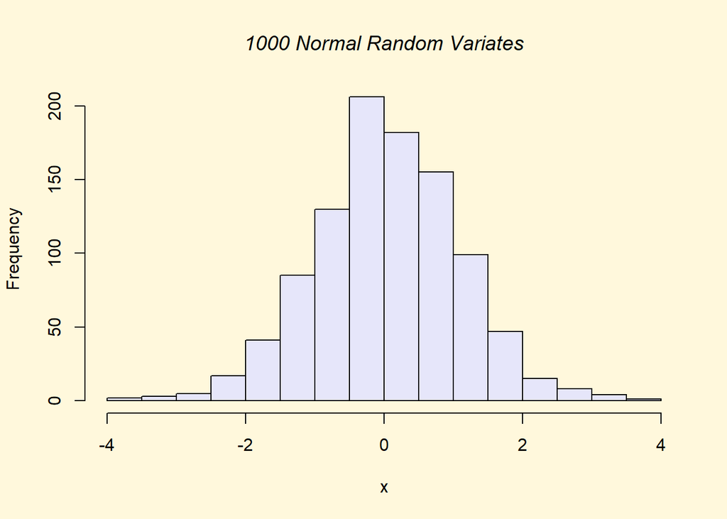

```
##
## > title(main="1000 Normal Random Variates", font.main=3)
##
## > ## A scatterplot matrix
## > ## The good old Iris data (yet again)
## >
## > pairs(iris[1:4], main="Edgar Anderson's Iris Data", font.main=4, pch=19)
```

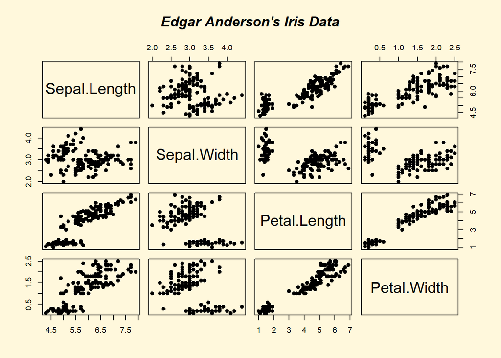

```
##
## > pairs(iris[1:4], main="Edgar Anderson's Iris Data", pch=21,
## +       bg = c("red", "green3", "blue")[unclass(iris$Species)])
```

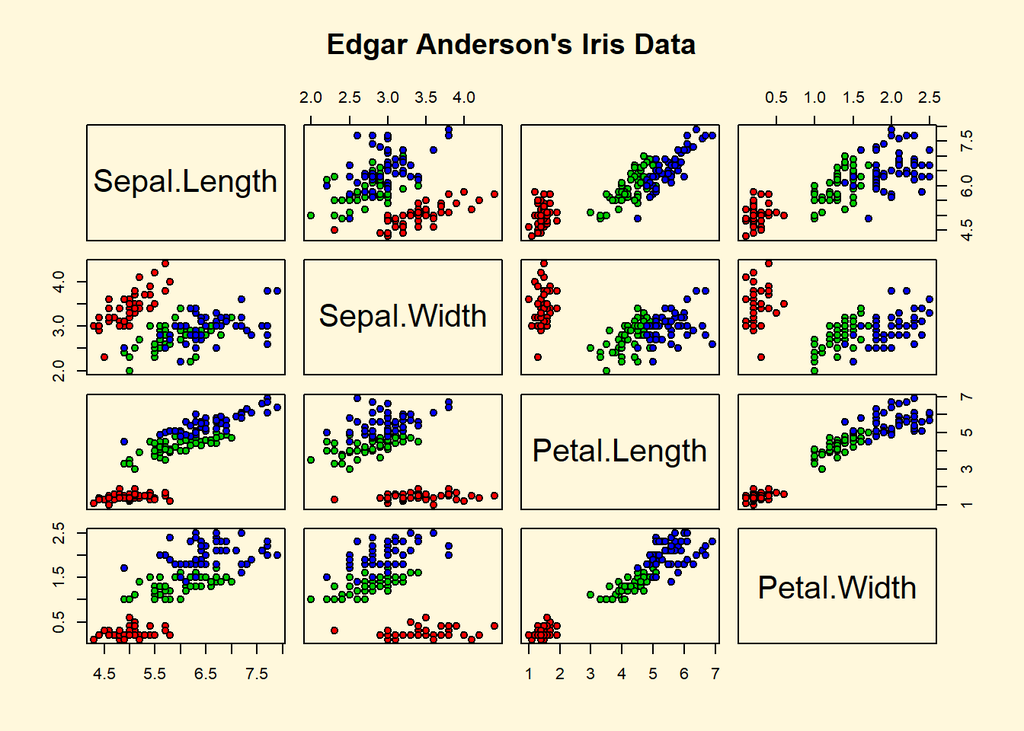

```
##
## > ## Contour plotting
## > ## This produces a topographic map of one of Auckland's many volcanic "peaks".
## >
## > x <- 10*1:nrow(volcano)
##
## > y <- 10*1:ncol(volcano)
##
## > lev <- pretty(range(volcano), 10)
##
## > par(bg = "lightcyan")
##
## > pin <- par("pin")
##
## > xdelta <- diff(range(x))
##
## > ydelta <- diff(range(y))
##
## > xscale <- pin[1]/xdelta
##
## > yscale <- pin[2]/ydelta
##
## > scale <- min(xscale, yscale)
##
## > xadd <- 0.5*(pin[1]/scale - xdelta)
##
## > yadd <- 0.5*(pin[2]/scale - ydelta)
##
## > plot(numeric(0), numeric(0),
## +      xlim = range(x)+c(-1,1)*xadd, ylim = range(y)+c(-1,1)*yadd,
## +      type = "n", ann = FALSE)
```

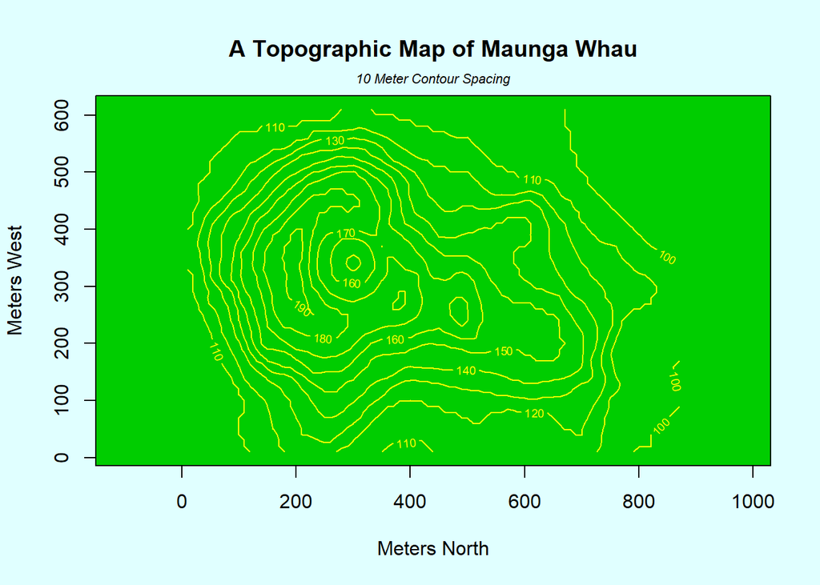

```
##
## > usr <- par("usr")
##
## > rect(usr[1], usr[3], usr[2], usr[4], col="green3")
##
## > contour(x, y, volcano, levels = lev, col="yellow", lty="solid", add=TRUE)
##
## > box()
##
## > title("A Topographic Map of Maunga Whau", font= 4)
##
## > title(xlab = "Meters North", ylab = "Meters West", font= 3)
##
## > mtext("10 Meter Contour Spacing", side=3, line=0.35, outer=FALSE,
## +       at = mean(par("usr")[1:2]), cex=0.7, font=3)
##
## > ## Conditioning plots
## >
## > par(bg="cornsilk")
##
## > coplot(lat ~ long | depth, data = quakes, pch = 21, bg = "green3")
```

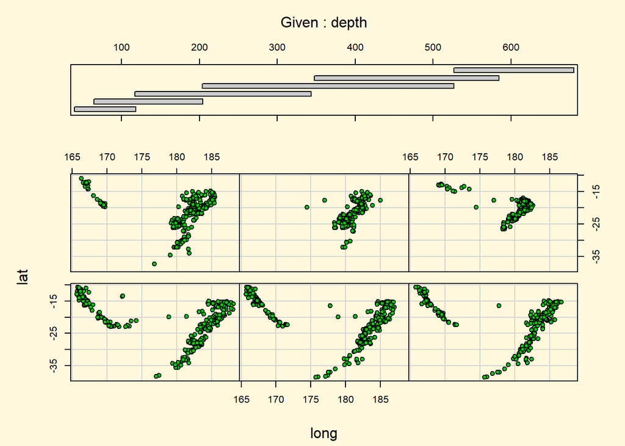

```
##
## > par(opar)
```

**Lets start**

But we need some data to plot

Lets load some data

Most probably, your data is in an excel file. If so, the most easiest way is to transfer your data from the excel to R through clipboard.

To do that

> 1. Paste this code in the console of R

*data <- read.table(file=“clipboard”,header=TRUE,sep=“\t”)*

> 2. Open your excel sheet, highlight your data and press ctrl+C “to copy them”
> 3. Put your cursor on your code (step 1), press ctrl+enter
> 4. Your data should be stored in R
> 5. To confirm, in the upper right panel of R studio, press on “Environment”, you should see your data there.

Try it yourself

Now, we will use a built-in data set in R called mtcars, lets recall this dataset

```r
head(mtcars)# asking R to show by default the first 6 rows of the dataset
```

```
##                    mpg cyl disp  hp drat    wt  qsec vs am gear carb
## Mazda RX4         21.0   6  160 110 3.90 2.620 16.46  0  1    4    4
## Mazda RX4 Wag     21.0   6  160 110 3.90 2.875 17.02  0  1    4    4
## Datsun 710        22.8   4  108  93 3.85 2.320 18.61  1  1    4    1
## Hornet 4 Drive    21.4   6  258 110 3.08 3.215 19.44  1  0    3    1
## Hornet Sportabout 18.7   8  360 175 3.15 3.440 17.02  0  0    3    2
## Valiant           18.1   6  225 105 2.76 3.460 20.22  1  0    3    1
```

This dataset about some cars parameters. to know more about it

```r
?mtcars
```

## 1. Line chart

**Lets plot a line chart where x is a scale and y is the value of (what we want to plot)**

For example

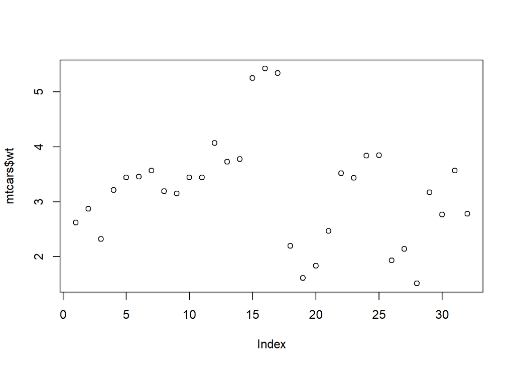

```r
plot(mtcars$wt)# plot(data name"data",variable name "represent y axis")
```

In base graphics, any calls for graphics will remove to the earlier one, simply because the default is to show 1 graph in the panel. try calling another graph

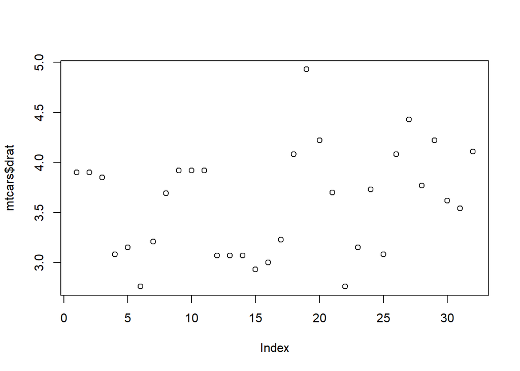

```r
plot(mtcars$drat)
```

BUT, if you want to show more than 1 graph, you need to setup the panel design first

par(mfrow=c(2,2)) # setting panel 2x2 ### par(mfrow=c(1,1))# to return to default setting 1 graph per window

lets try it using wt, drat, qsec, and hp you should get something like this

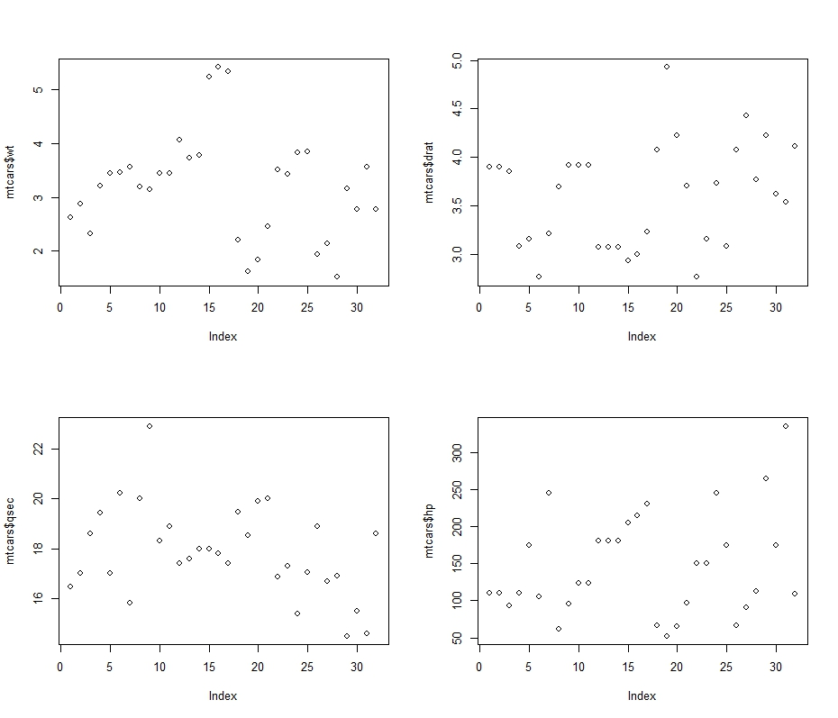

my graph

*Not difficult right?*

**Ok, lets add some lines and color**

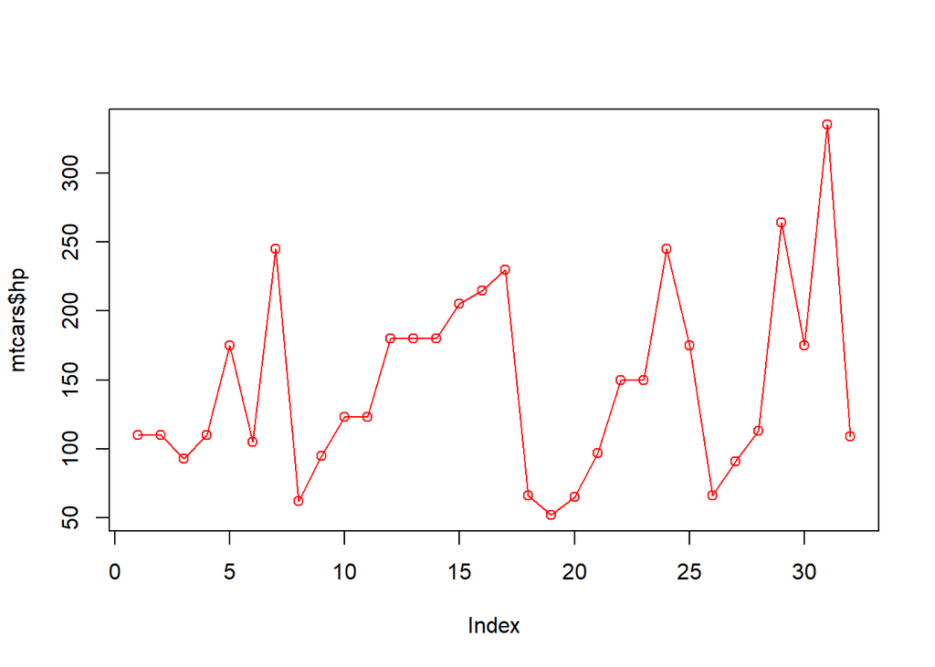

```r
plot(mtcars$hp,type="o",col="red")
```

**In R there is always a wide functionality even in this base function. to know more about any function in details , just type ? before the function name**

**Try this ? plot**

**On the latest code typr =“o” means over plot “lines over point”, try exchange it to s, h, or others.**

**“p” for points, “l” for lines, “b” for both, “c” for the lines part alone of “b”, “o” for both ‘overplotted’, “h” for ‘histogram’ like (or ‘high-density’) vertical lines, “s” for stair steps, “S” for other steps, see ‘Details’ below, “n” for no plotting.**

**OK clear your plot by pressing on the eraser button (or type “dev.off()”) in the console.**

**In most cases, we would like to compare several variables**

Lets call line graph for the wt

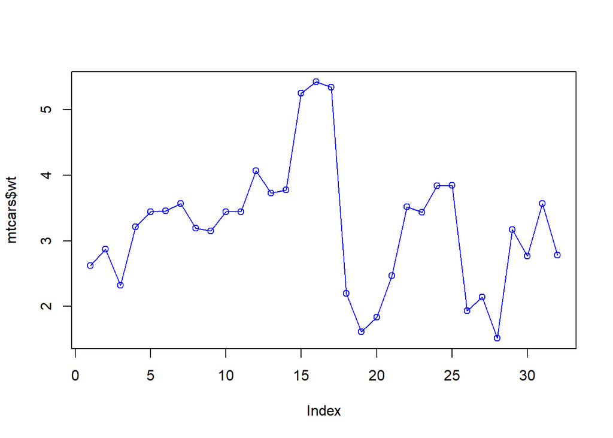

```r
plot(mtcars$wt,type="o", col="blue")
```

**Then ill ask R to overlay the drat data on the existing graph**

**lines(mtcars$drat,type=“o”,pch=22, col=“red”) # ill change its color to red and points to square**

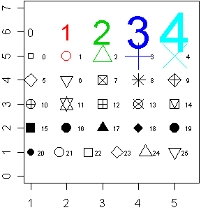

my graph

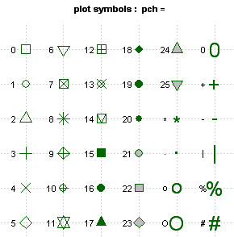

my graph

**Lets add a title for this silly graph**

*title(main=“my first silly graph!”, col.main=“black”, font.main=4)*

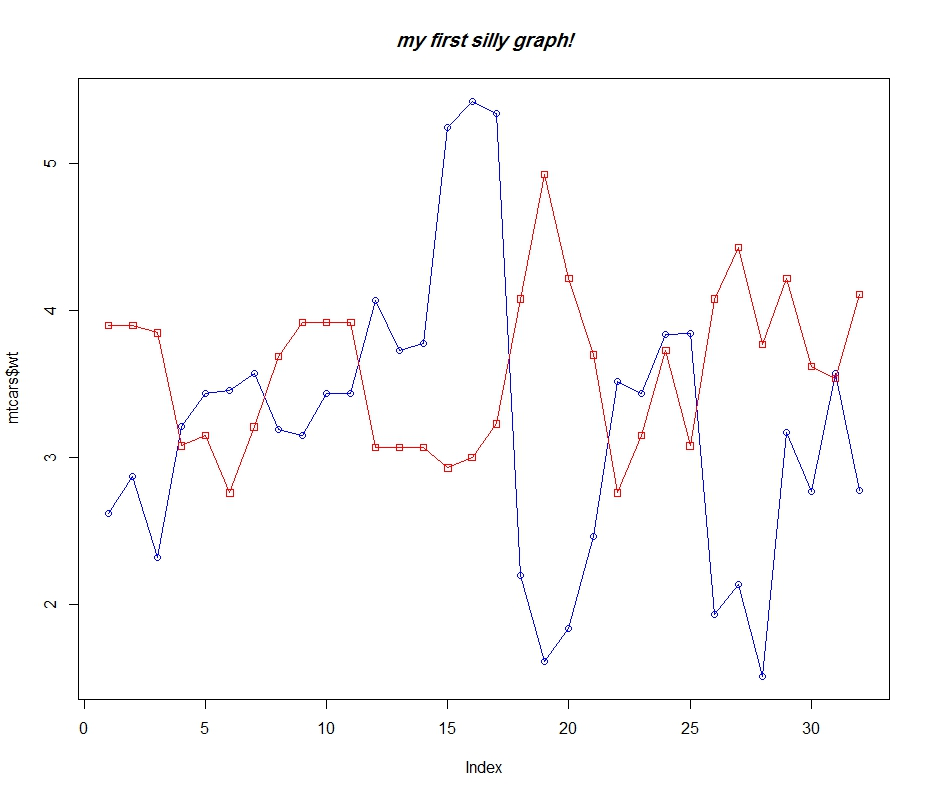

my graph

You can change the axis range by calling “ylim=c(0,12)) for y axis and xlim=c(0,50)) for x axis”

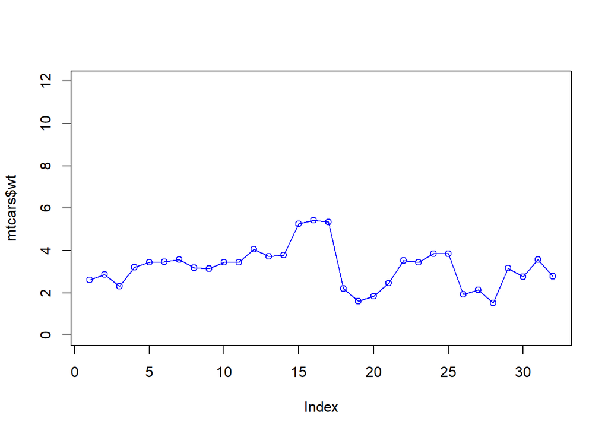

```r
plot(mtcars$wt,type="o", col="blue",ylim=c(0,12))
```

You can always change the x or y axis title

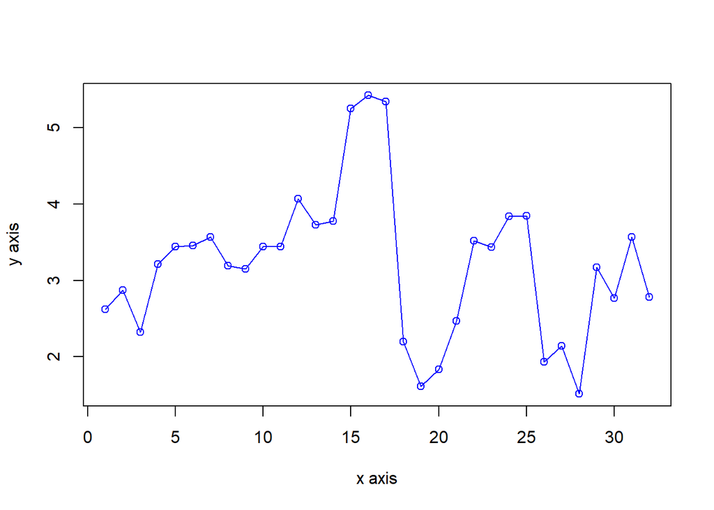

```r
plot(mtcars$wt,type="o", col="blue",xlab="x axis",ylab="y axis")
```

To add a legend

```r
plot(mtcars$wt,type="o", col="blue",xlab="x axis",ylab="y axis")
```

[output not shown]

Add the legend

*legend(1, 5, c(“weight”), col=c(“blue”), cex=0.8, pch=21, lty=1)*

cex: for legend box pch: dot shape lty: line shape

Try playing with these parameters

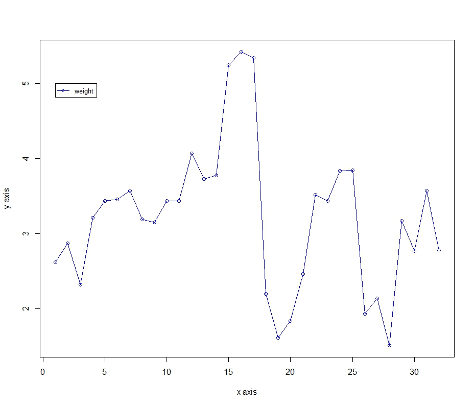

my graph